# MA331-Report: 2213212

TED Talks by Speaker Kio Stark and Speaker Hans Rosling

Gaurav

## Introduction

This report explores the analysis of speeches illustrated by renowned TED speakers Kio Stark and Hans Rosling. Kio Stark discusses the importance of interacting with strangers in her 2016 Ted talk, encouraging the audience to come out of their fear of strangers. Hans Rosling is a renowned statistician with Ted talks on “The Best Stats You’ve Ever Seen” , “Insights on HIV, In Stunning Data Visuals”, and “New Insights on Poverty”, from 2006–2009. All of his talks are presented with data and visual analyses and give mind-boggling insights on world issues like HIV and poverty. This report will perform a sentiment analysis on their speeches and investigate how their emotions and communication influence listeners, comparing the overall tone of speakers.

## Methods

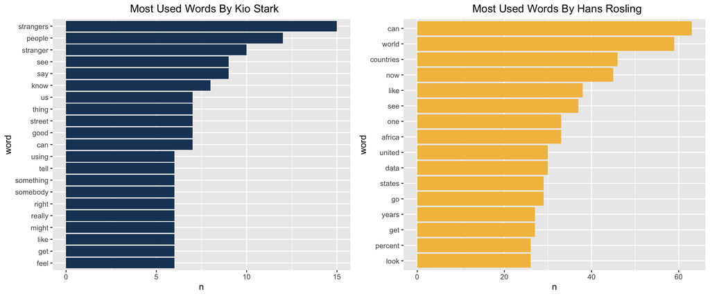

The visualisation below is a scatter plot that demonstrates the most frequently used words by Kio Stark and Hans Rosling. The words closer to the line indicate a similar use of words.

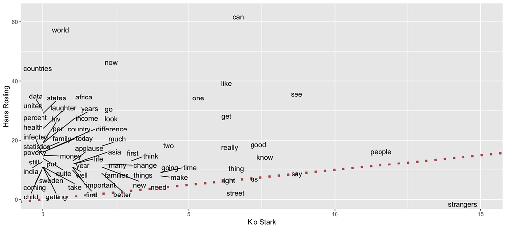

The table for sentiments is obtained using the get.sentiments() function. The NRC lexicon library is used to detect sentiments. It assigns sentiment to each word, and the total count is calculated for both speakers. The table shows a summary of the sentiment distribution for two speakers and is used to determine the sentiment categories that are most closely connected to each speaker. The most common positive and negative sentiments are also extracted from the already calculated variable to specifically compare the overall tone of the speech.

# Results

Together with the odds ratio and log odds ratio for each sentiment category, we can also observe the frequency counts for each speaker for each sentiment category. The odds ratio is the likelihood that a specific sentiment category will be related with one speaker over another, while the log odds ratio is the odds ratio’s natural logarithm.

```
## # A tibble: 10 × 5
##    sentiment    `Hans Rosling` `Kio Stark`    OR  log_OR
##    <fct>                 <int>       <int> <dbl>   <dbl>
##  1 anger                    69          19 1.18   0.169
##  2 anticipation            174          31 0.734 -0.309
##  3 disgust                  48          11 0.975 -0.0249
##  4 fear                     92          35 1.69   0.527
##  5 joy                     152          34 0.947 -0.0540
##  6 negative                160          45 1.23   0.206
##  7 positive                324          82 1.10   0.0988
##  8 sadness                  97          16 0.688 -0.375
##  9 surprise                 92          19 0.872 -0.136
## 10 trust                   202          39 0.799 -0.225
```

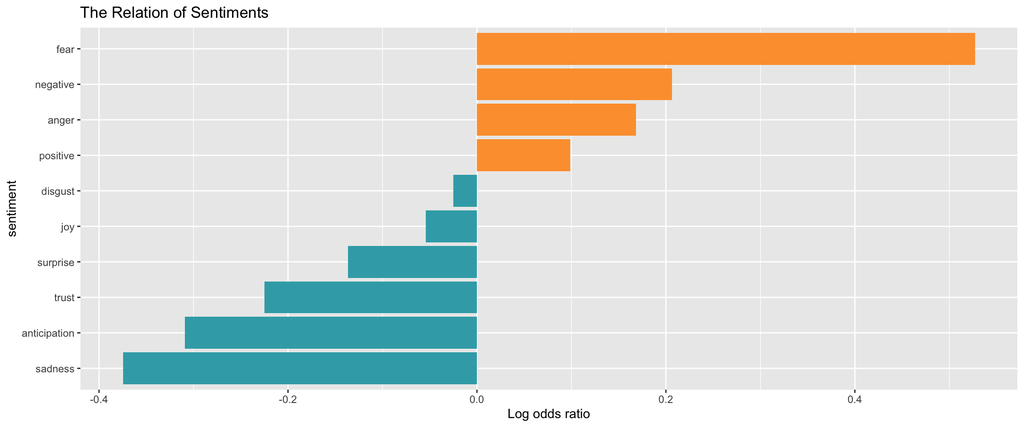

The bar graph below shows the most common positive and negative words used by the speakers. The quantity and distribution of positive and negative words in a text are used to assess the tone of the content. In our results, there are more positive than negative words used in the text, which gives the text an overall positive tone. It can also be concluded that it has overall positive effect on the listener of these speeches.

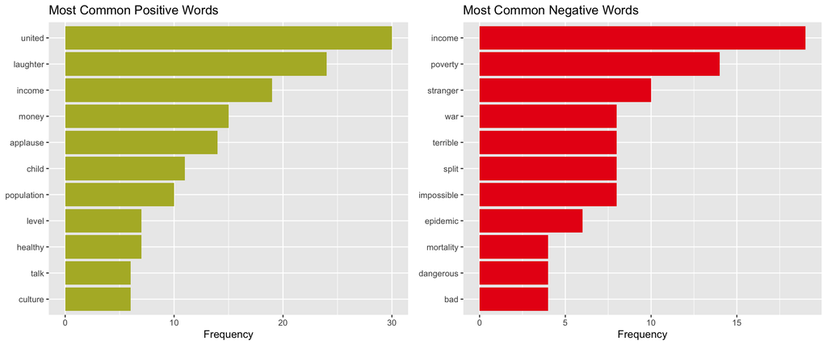

In our findings, it can be said that Kio Stark and Hans Rosling have a unique style of communicating, as some sentiments are distinctly related with one speaker over the other based on the sentiment and log odds ratios. The choice of more positive words than negative words has a positive impact on the listener. Thus, the overall tone is positively influenced by the use of more positive words. Nonetheless, this analysis provides useful insight about the way of communicating and the usage of words by the speakers.